# Capstone Project - Professional Google Data Analytics Certificate

Nam Tran

2022-07-13

# Case Study: How does a bike share navigate speedy success?

# Introduction:

- This project is the capstone assignment for the Google Data Analytics Professional Certificate program. I applied all the knowledge, skills, and competencies I gained from earlier courses (analysis phases, analytics thinking, data processing, data cleaning, data analyzing, and visualization) to address business objectives.
- This project will analyze publicly available data sets provided by the course for a bike share program based in Chicago.

### Scenario:

- This project is belonged to the marketing analyst team at Cyclistic, a bike-share company in Chicago. Until now, Cyclistic’s marketing strategy relied on building general awareness and appealing to broad consumer segments. One approach that helped make these things possible was the flexibility of its pricing plans: single-ride passes, full-day passes, and annual memberships. Customers who purchase single-ride or full-day passes are referred to as casual riders. Customers who purchase annual memberships are Cyclistic members.
- The director of marketing believes the company’s future success depends on maximizing the number of annual memberships. Therefore, analytics team wants to understand how casual riders and annual members use Cyclistic bikes differently. From these insights, marketing team can design good marketing campaigns.

# Business Objectives:

- How do casual riders and annual memberships use Cyclistics services differently from 06/2021 to 05/2022? From these insights, the marketing team will design a new marketing strategy to convert casual riders into annual members.
- Are there any trends in history data that can help predict the future demand of customers.

# Data Collection:

- The data for the project is provided by Motivate International, Inc. under this license.
- The data was collected and downloaded from [link](https://divvy-tripdata.s3.amazonaws.com/index.html).
- For this analysis, 12 months data was used; from June 2021 to May 2022. The data was accessible in a zip folder, and downloaded to a personal computer. The data are organized monthly, and merged into only one data.

### **Load Library**

```r
library(dplyr)
library(readr)
library(geosphere)
library(ggplot2)
library(scales)
library(lubridate)
library(tidyverse)
library(skimr)
library(kableExtra)
library(cowplot)
```

### **Import Data**

```r
trip_202106<-read.csv("202106-divvy-tripdata.csv")
trip_202107<-read.csv("202107-divvy-tripdata.csv")
trip_202108<-read.csv("202108-divvy-tripdata.csv")
trip_202109<-read.csv("202109-divvy-tripdata.csv")
trip_202110<-read.csv("202110-divvy-tripdata.csv")
trip_202111<-read.csv("202111-divvy-tripdata.csv")
trip_202112<-read.csv("202112-divvy-tripdata.csv")
trip_202201<-read.csv("202201-divvy-tripdata.csv")
trip_202202<-read.csv("202202-divvy-tripdata.csv")
trip_202203<-read.csv("202203-divvy-tripdata.csv")
trip_202204<-read.csv("202204-divvy-tripdata.csv")
trip_202205<-read.csv("202205-divvy-tripdata.csv")
```

### **Merging Data**

- After checking these datasets have same variable names. I merged these data into only one data.

```r
Trip_12months <- rbind(trip_202106, trip_202107, trip_202108, trip_202109,trip_202110,trip_202111,trip_202112,trip_202201,trip_202202,trip_202203,trip_202204,trip_202205)
```

# Data Processing:

### Data Overview:

```r
head(Trip_12months)
```

```
##            ride_id rideable_type          started_at            ended_at
## 1 99FEC93BA843FB20 electric_bike 2021-06-13 14:31:28 2021-06-13 14:34:11
## 2 06048DCFC8520CAF electric_bike 2021-06-04 11:18:02 2021-06-04 11:24:19
## 3 9598066F68045DF2 electric_bike 2021-06-04 09:49:35 2021-06-04 09:55:34
## 4 B03C0FE48C412214 electric_bike 2021-06-03 19:56:05 2021-06-03 20:21:55
## 5 B9EEA89F8FEE73B7 electric_bike 2021-06-04 14:05:51 2021-06-04 14:09:59
## 6 62B943CEAAA420BA electric_bike 2021-06-03 19:32:01 2021-06-03 19:38:46
##   start_station_name start_station_id end_station_name end_station_id start_lat
## 1                                                                         41.80
## 2                                                                         41.79
## 3                                                                         41.80
## 4                                                                         41.78
## 5                                                                         41.80
## 6                                                                         41.78
##   start_lng end_lat end_lng member_casual
## 1    -87.59   41.80  -87.60        member
## 2    -87.59   41.80  -87.60        member
## 3    -87.60   41.79  -87.59        member
## 4    -87.58   41.80  -87.60        member
## 5    -87.59   41.79  -87.59        member
## 6    -87.58   41.78  -87.58        member
```

```r
glimpse(Trip_12months)
```

```
## Rows: 5,860,776
## Columns: 13
## $ ride_id            <chr> "99FEC93BA843FB20", "06048DCFC8520CAF", "9598066F68~
## $ rideable_type      <chr> "electric_bike", "electric_bike", "electric_bike", ~
## $ started_at         <chr> "2021-06-13 14:31:28", "2021-06-04 11:18:02", "2021~
## $ ended_at           <chr> "2021-06-13 14:34:11", "2021-06-04 11:24:19", "2021~
## $ start_station_name <chr> "", "", "", "", "", "", "", "", "", "", "", "", "",~
## $ start_station_id   <chr> "", "", "", "", "", "", "", "", "", "", "", "", "",~
## $ end_station_name   <chr> "", "", "", "", "", "", "", "", "", "Michigan Ave &~
## $ end_station_id     <chr> "", "", "", "", "", "", "", "", "", "13042", "", ""~
## $ start_lat          <dbl> 41.80, 41.79, 41.80, 41.78, 41.80, 41.78, 41.79, 41~
## $ start_lng          <dbl> -87.59, -87.59, -87.60, -87.58, -87.59, -87.58, -87~
## $ end_lat            <dbl> 41.80000, 41.80000, 41.79000, 41.80000, 41.79000, 4~
## $ end_lng            <dbl> -87.6000, -87.6000, -87.5900, -87.6000, -87.5900, -~
## $ member_casual      <chr> "member", "member", "member", "member", "member", "~
```

```r
colnames(Trip_12months)
```

```
##  [1] "ride_id"            "rideable_type"      "started_at"
##  [4] "ended_at"           "start_station_name" "start_station_id"
##  [7] "end_station_name"   "end_station_id"     "start_lat"
## [10] "start_lng"          "end_lat"            "end_lng"
## [13] "member_casual"
```

### Data Cleaning and Formatting:

```r
skim(Trip_12months)
```

Data summary

| Name | Trip_12months |
| --- | --- |
| Number of rows | 5860776 |
| Number of columns | 13 |
| _______________________ |  |
| Column type frequency: |  |
| character | 9 |
| numeric | 4 |
| ________________________ |  |
| Group variables | None |

**Variable type: character**

| skim_variable | n_missing | complete_rate | min | max | empty | n_unique | whitespace |
| --- | --- | --- | --- | --- | --- | --- | --- |
| ride_id | 0 | 1 | 16 | 16 | 0 | 5860776 | 0 |
| rideable_type | 0 | 1 | 11 | 13 | 0 | 3 | 0 |
| started_at | 0 | 1 | 19 | 19 | 0 | 4896834 | 0 |
| ended_at | 0 | 1 | 19 | 19 | 0 | 4893478 | 0 |
| start_station_name | 0 | 1 | 0 | 53 | 823167 | 1106 | 0 |
| start_station_id | 0 | 1 | 0 | 44 | 823164 | 1064 | 0 |
| end_station_name | 0 | 1 | 0 | 53 | 878338 | 1113 | 0 |
| end_station_id | 0 | 1 | 0 | 44 | 878338 | 1069 | 0 |
| member_casual | 0 | 1 | 6 | 6 | 0 | 2 | 0 |

**Variable type: numeric**

| skim_variable | n_missing | complete_rate | mean | sd | p0 | p25 | p50 | p75 | p100 | hist |
| --- | --- | --- | --- | --- | --- | --- | --- | --- | --- | --- |
| start_lat | 0 | 1 | 41.90 | 0.05 | 41.64 | 41.88 | 41.90 | 41.93 | 45.64 | ▇▁▁▁▁ |
| start_lng | 0 | 1 | -87.65 | 0.03 | -87.84 | -87.66 | -87.64 | -87.63 | -73.80 | ▇▁▁▁▁ |
| end_lat | 5036 | 1 | 41.90 | 0.05 | 41.39 | 41.88 | 41.90 | 41.93 | 42.17 | ▁▁▁▇▁ |
| end_lng | 5036 | 1 | -87.65 | 0.03 | -88.97 | -87.66 | -87.64 | -87.63 | -87.49 | ▁▁▁▁▇ |

- **ride_id**

```r
n_unique(Trip_12months$ride_id)
```

```
## [1] 5860776
```

- **rideable_type**

```r
table(Trip_12months$rideable_type)
```

```
##
##  classic_bike   docked_bike electric_bike
##       3217737        274447       2368592
```

```r
sum(is.null(Trip_12months$rideable_type))
```

```
## [1] 0
```

```r
sum(is.na(Trip_12months$rideable_type))
```

```
## [1] 0
```

- **started_at**

Transform this variable from character to datetime datatype

```r
#head(Trip_12months$started_at)
#sum(nchar(Trip_12months$started_at) != 19)
Trip_12months$started_at <-  as.POSIXct(Trip_12months$started_at)
```

- **ended_at**

Transform this variable from character to datetime datatype

```r
#sum(nchar(Trip_12months$ended_at) != 19)
Trip_12months$ended_at <- as.POSIXct(Trip_12months$ended_at)
```

- Adding **Date, Month, Day_Of_Week, Start_Service_Hour and Ride_Duration variables** to better understand data

```r
Trip_12months$Ride_Date <- as.Date(Trip_12months$started_at)

Trip_12months$Month <- format(as.Date(Trip_12months$started_at), "%b_%y")
Trip_12months$Month <- ordered(Trip_12months$Month, levels=c("Jun_21", "Jul_21", "Aug_21", "Sep_21", "Oct_21", "Nov_21", "Dec_21", "Jan_22", "Feb_22", "Mar_22", "Apr_22", "May_22", "Jun_22"))

Trip_12months$Day_Of_Month <- format(as.Date(Trip_12months$started_at), "%d")

Trip_12months$Day_Of_Week <- format(as.Date(Trip_12months$started_at), "%A")
Trip_12months$Day_Of_Week <- ordered(Trip_12months$Day_Of_Week, levels=c("Monday", "Tuesday", "Wednesday", "Thursday", "Friday", "Saturday", "Sunday"))

Trip_12months$Hour <- hour(Trip_12months$started_at)

Trip_12months$Ride_Duration <- difftime(Trip_12months$ended_at, Trip_12months$started_at, units = "mins")
Trip_12months$Ride_Duration <- as.double(Trip_12months$Ride_Duration)

Trip_12months$WkDayWkEnd <- ifelse(Trip_12months$Day_Of_Week %in% c("Saturday", "Sunday"),"WeekEnd","WeekDay")
```

- Removing trips having duration < 0.

```r
Trip_12months <- Trip_12months[!(Trip_12months$Ride_Duration < 0),]
```

- **start_station_name**

```r
#sum(is.na(Trip_12months$start_station_name))
#sum(is.null(Trip_12months$start_station_name))
#sum(Trip_12months$start_station_name =="")
Trip_12months$start_station_name[Trip_12months$start_station_name ==""] <- NA
```

- **end_station_name**

```r
#sum(is.na(Trip_12months$end_station_name))
#sum(is.null(Trip_12months$end_station_name))
#sum(Trip_12months$end_station_name =="")
Trip_12months$end_station_name[Trip_12months$end_station_name ==""] <- NA
```

- **member_casual**

```r
table(Trip_12months$member_casual)
```

```
##
##  casual  member
## 2559796 3300841
```

```r
sum(Trip_12months$member_casual %in% c("casual","member"))
```

```
## [1] 5860637
```

- In this project, we will not consider the longitude and latitude information. I will drop **start_station_id, end_station_id, start_lat, start_lng, end_lat, end_lng variables**

```r
Trip_12months = subset(Trip_12months, select = -c(start_station_id, end_station_id, start_lat, start_lng, end_lat, end_lng))
```

# ANALYZE DATA:

### **Data Exploratory Analysis**

- **The ride length**

```r
mean(Trip_12months$Ride_Duration)
```

```
## [1] 20.69135
```

```r
max(Trip_12months$Ride_Duration)
```

```
## [1] 55944.15
```

```r
min(Trip_12months$Ride_Duration)
```

```
## [1] 0
```

```r
median(Trip_12months$Ride_Duration)
```

```
## [1] 11.33333
```

- **Customer Type and Ride Length**

```r
Ride_Length_Sum <- Trip_12months %>%
  dplyr::group_by(member_casual) %>%
  dplyr::summarise(
    Number_Of_Ride = n(),
    Average_Duration = mean(Ride_Duration)
  )
Ride_Length_Sum  %>%
  knitr::kable(caption = "Ride Length Summary", digits = 2) %>%
  kable_classic(full_width = F, html_font = "Arial")
```

Ride Length Summary

| member_casual | Number_Of_Ride | Average_Duration |
| --- | --- | --- |
| casual | 2559796 | 30.55 |
| member | 3300841 | 13.04 |

- **Customer Type, Ride Type and Ride Length**

```r
Ride_Type_Sum <- Trip_12months %>%
  dplyr::group_by(member_casual, rideable_type) %>%
  dplyr::summarise(
    Number_Of_Ride = n(),
    Average_Duration = mean(Ride_Duration)
  )
Ride_Type_Sum %>%
  knitr::kable(caption = "Ride Type Summary", digits = 2) %>%
  kableExtra::kable_styling() %>%
  kable_classic(full_width = F, html_font = "Arial")
```

Ride Type Summary

| member_casual | rideable_type | Number_Of_Ride | Average_Duration |
| --- | --- | --- | --- |
| casual | classic_bike | 1236507 | 28.72 |
| casual | docked_bike | 274442 | 83.13 |
| casual | electric_bike | 1048847 | 18.96 |
| member | classic_bike | 1981150 | 13.74 |
| member | electric_bike | 1319691 | 12.01 |

- **Top 5 Start Station by Customer Type**

```r
Start_Station_Sum <- Trip_12months %>%
  dplyr::group_by(member_casual, start_station_name) %>%
  dplyr::summarise(Number_Of_Ride =n()) %>%
  dplyr::arrange(desc(Number_Of_Ride)) %>%
  na.omit(start_station_name)
Start_Station_Sum_Casual <- filter(Start_Station_Sum, member_casual =="casual") %>%
  slice(1:5)
Start_Station_Sum_Member <- filter(Start_Station_Sum, member_casual =="member") %>%
  slice(1:5)

Start_Station_Sum_Casual %>%
  knitr::kable(caption = "Top 5 Start Station for Cusual Customer", digits = 2) %>%
  kableExtra::kable_styling() %>%
  kable_classic(full_width = F, html_font = "Arial")
```

Top 5 Start Station for Cusual Customer

| member_casual | start_station_name | Number_Of_Ride |
| --- | --- | --- |
| casual | Streeter Dr & Grand Ave | 67396 |
| casual | Millennium Park | 31955 |
| casual | Michigan Ave & Oak St | 29226 |
| casual | DuSable Lake Shore Dr & Monroe St | 24191 |
| casual | Shedd Aquarium | 22868 |

```r
Start_Station_Sum_Member %>%
  knitr::kable(caption = "Top 5 Start Station for Membership", digits = 2) %>%
  kableExtra::kable_styling() %>%
  kable_classic(full_width = F, html_font = "Arial")
```

Top 5 Start Station for Membership

| member_casual | start_station_name | Number_Of_Ride |
| --- | --- | --- |
| member | Kingsbury St & Kinzie St | 26127 |
| member | Clark St & Elm St | 24889 |
| member | Wells St & Concord Ln | 24249 |
| member | Wells St & Elm St | 21159 |
| member | Ellis Ave & 60th St | 19448 |

- **Top 5 End Station by Customer Type**

```r
End_Station_Sum <- Trip_12months %>%
  dplyr::group_by(member_casual, end_station_name) %>%
  dplyr::summarise(Number_Of_Ride =n()) %>%
  dplyr::arrange(desc(Number_Of_Ride)) %>%
  na.omit(start_station_name)
End_Station_Sum_Casual <- filter(End_Station_Sum, member_casual =="casual") %>%
  slice(1:5)
End_Station_Sum_Member <- filter(End_Station_Sum, member_casual =="member") %>%
  slice(1:5)

End_Station_Sum_Casual %>%
  knitr::kable(caption = "Top 5 End Station for Cusual Customer", digits = 2) %>%
  kableExtra::kable_styling() %>%
  kable_classic(full_width = F, html_font = "Arial")
```

Top 5 End Station for Cusual Customer

| member_casual | end_station_name | Number_Of_Ride |
| --- | --- | --- |
| casual | Streeter Dr & Grand Ave | 69467 |
| casual | Millennium Park | 32780 |
| casual | Michigan Ave & Oak St | 30639 |
| casual | DuSable Lake Shore Dr & North Blvd | 22400 |
| casual | DuSable Lake Shore Dr & Monroe St | 22257 |

```r
End_Station_Sum_Member %>%
  knitr::kable(caption = "Top 5 End Station for Membership", digits = 2) %>%
  kableExtra::kable_styling() %>%
  kable_classic(full_width = F, html_font = "Arial")
```

Top 5 End Station for Membership

| member_casual | end_station_name | Number_Of_Ride |
| --- | --- | --- |
| member | Kingsbury St & Kinzie St | 26009 |
| member | Clark St & Elm St | 24899 |
| member | Wells St & Concord Ln | 24863 |
| member | Wells St & Elm St | 21670 |
| member | Dearborn St & Erie St | 19802 |

- **Customer Type, Ride Date and Ride Length**

```r
Trip_Date_Sum <- Trip_12months %>%
  dplyr::group_by(member_casual, Ride_Date) %>%
  dplyr::summarise(
    Number_Of_Trip = n(),
    Average_Of_Duaration = mean(Ride_Duration)
  )
```

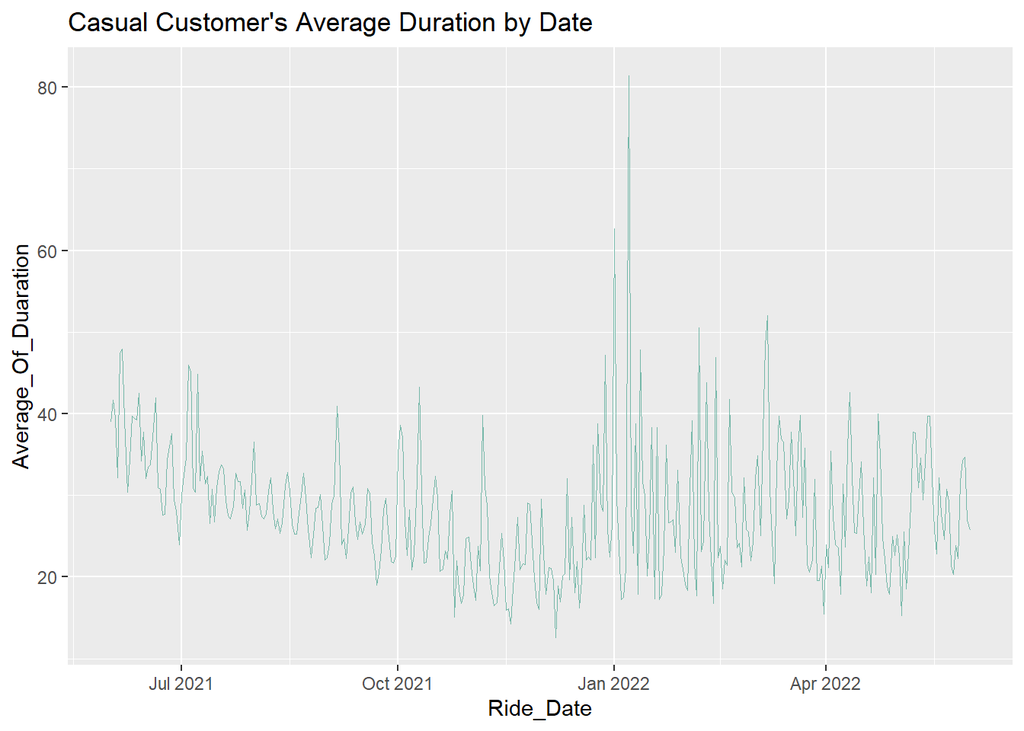

```r
Trip_Date_Sum_Casual <- filter(Trip_Date_Sum, member_casual =="casual")
Trip_Date_Sum_Member <- filter(Trip_Date_Sum, member_casual =="member")

ggplot(Trip_Date_Sum_Casual , aes(x=Ride_Date, y=Average_Of_Duaration)) +
 geom_line(color="#69b3a2", size=0.2, alpha=0.9) +
  ggtitle("Casual Customer's Average Duration by Date")
```

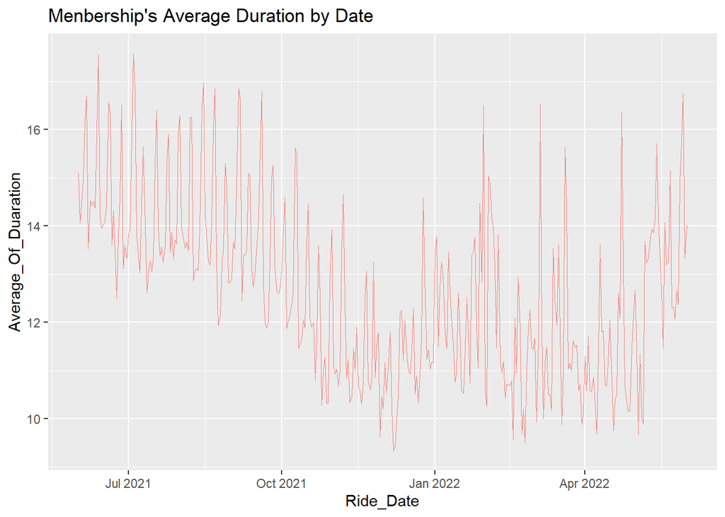

```r
ggplot(Trip_Date_Sum_Member, aes(x=Ride_Date, y=Average_Of_Duaration)) +
 geom_line(color="#F8766D", size=0.2, alpha=0.9) +
  ggtitle("Menbership's Average Duration by Date")
```

* **Customer Type, Month and Ride Length**

```r
Month_Sum <- Trip_12months %>%
  dplyr::group_by(member_casual, Month) %>%
  dplyr::summarise(
    Number_Of_Ride = n(),
    Average_Duration = mean(Ride_Duration)
  )
Month_Sum  %>%
  knitr::kable(caption = "Customer Type and Months", digits = 2) %>%
  kableExtra::kable_styling() %>%
  kable_classic(full_width = F, html_font = "Arial")
```

Customer Type and Months

| member_casual | Month | Number_Of_Ride | Average_Duration |
| --- | --- | --- | --- |
| casual | Jun_21 | 368955 | 37.15 |
| casual | Jul_21 | 439450 | 32.73 |
| casual | Aug_21 | 415658 | 28.92 |
| casual | Sep_21 | 363559 | 27.81 |
| casual | Oct_21 | 258354 | 28.62 |
| casual | Nov_21 | 106916 | 23.30 |
| casual | Dec_21 | 69774 | 23.30 |
| casual | Jan_22 | 18907 | 30.68 |
| casual | Feb_22 | 21168 | 26.81 |
| casual | Mar_22 | 89998 | 32.60 |
| casual | Apr_22 | 126095 | 29.53 |
| casual | May_22 | 279396 | 30.88 |
| casual | Jun_22 | 1566 | 25.69 |
| member | Jun_21 | 357238 | 14.68 |
| member | Jul_21 | 380048 | 14.23 |
| member | Aug_21 | 392123 | 14.12 |
| member | Sep_21 | 391888 | 13.74 |
| member | Oct_21 | 374954 | 12.50 |
| member | Nov_21 | 252432 | 11.32 |
| member | Dec_21 | 178652 | 10.99 |
| member | Jan_22 | 85318 | 12.01 |
| member | Feb_22 | 93841 | 11.40 |
| member | Mar_22 | 194445 | 11.96 |
| member | Apr_22 | 244786 | 11.48 |
| member | May_22 | 353410 | 13.36 |
| member | Jun_22 | 1706 | 14.01 |

- **Customer Type, Day of Week and Ride Length**

```r
DayOfWeek_Sum <- Trip_12months %>%
  dplyr::group_by(member_casual, Day_Of_Week) %>%
  dplyr::summarise(
    Number_Of_Ride = n(),
    Average_Duration = mean(Ride_Duration)
  )
DayOfWeek_Sum  %>%
  knitr::kable(caption = "Customer Type and Day of Week", digits = 2) %>%
  kableExtra::kable_styling() %>%
  kable_classic(full_width = F, html_font = "Arial")
```

Customer Type and Day of Week

| member_casual | Day_Of_Week | Number_Of_Ride | Average_Duration |
| --- | --- | --- | --- |
| casual | Monday | 310682 | 31.47 |
| casual | Tuesday | 283181 | 26.44 |
| casual | Wednesday | 282098 | 26.62 |
| casual | Thursday | 298857 | 27.39 |
| casual | Friday | 353594 | 28.45 |
| casual | Saturday | 527191 | 32.86 |
| casual | Sunday | 504193 | 35.43 |
| member | Monday | 454222 | 12.72 |
| member | Tuesday | 515919 | 12.31 |
| member | Wednesday | 510538 | 12.29 |
| member | Thursday | 498415 | 12.36 |
| member | Friday | 466666 | 12.73 |
| member | Saturday | 441747 | 14.48 |
| member | Sunday | 413334 | 14.90 |

- **Customer Type, Start Time and Ride Length**

```r
Sart_Time_Sum <- Trip_12months %>%
  dplyr::group_by(member_casual, Hour) %>%
  dplyr::summarise(
    Number_Of_Ride = n(),
    Average_Duration = mean(Ride_Duration)
  )
Sart_Time_Sum  %>%
  knitr::kable(caption = "Customer Type and Start Time", digits = 2) %>%
  kableExtra::kable_styling() %>%
  kable_classic(full_width = F, html_font = "Arial")
```

Customer Type and Start Time

| member_casual | Hour | Number_Of_Ride | Average_Duration |
| --- | --- | --- | --- |
| casual | 0 | 53770 | 34.90 |
| casual | 1 | 38568 | 37.95 |
| casual | 2 | 26246 | 42.63 |
| casual | 3 | 14655 | 42.09 |
| casual | 4 | 10218 | 48.71 |
| casual | 5 | 13322 | 22.72 |
| casual | 6 | 27502 | 20.80 |
| casual | 7 | 51038 | 20.22 |
| casual | 8 | 68672 | 22.96 |
| casual | 9 | 78986 | 27.49 |
| casual | 10 | 106180 | 32.32 |
| casual | 11 | 137705 | 32.71 |
| casual | 12 | 161575 | 31.91 |
| casual | 13 | 172004 | 32.55 |
| casual | 14 | 177127 | 32.79 |
| casual | 15 | 189633 | 32.27 |
| casual | 16 | 206972 | 29.56 |
| casual | 17 | 237874 | 28.34 |
| casual | 18 | 216144 | 28.32 |
| casual | 19 | 168535 | 29.31 |
| casual | 20 | 123725 | 30.35 |
| casual | 21 | 105776 | 31.09 |
| casual | 22 | 98450 | 30.34 |
| casual | 23 | 75119 | 32.04 |
| member | 0 | 35392 | 13.46 |
| member | 1 | 23292 | 14.39 |
| member | 2 | 13594 | 15.03 |
| member | 3 | 8038 | 16.05 |
| member | 4 | 9088 | 13.34 |
| member | 5 | 33179 | 11.38 |
| member | 6 | 88814 | 11.56 |
| member | 7 | 168041 | 11.93 |
| member | 8 | 197647 | 11.78 |
| member | 9 | 143244 | 11.94 |
| member | 10 | 137801 | 12.85 |
| member | 11 | 165069 | 13.13 |
| member | 12 | 190346 | 12.75 |
| member | 13 | 186839 | 12.88 |
| member | 14 | 182990 | 13.30 |
| member | 15 | 213253 | 13.31 |
| member | 16 | 279322 | 13.53 |
| member | 17 | 343926 | 13.71 |
| member | 18 | 286505 | 13.58 |
| member | 19 | 206276 | 13.41 |
| member | 20 | 141477 | 13.38 |
| member | 21 | 108004 | 13.01 |
| member | 22 | 82521 | 13.12 |
| member | 23 | 56183 | 13.68 |

- **User Type, Start Time, Weekday, Weekend and Ride Length Analysis**

```r
WDayWEnd_Sum <- Trip_12months %>%
  dplyr::group_by(member_casual, WkDayWkEnd, Hour) %>%
  dplyr::summarise(
    Number_Of_Ride = n(),
    Average_Duration = mean(Ride_Duration)) %>%
  unite("user_type", c("member_casual","WkDayWkEnd"), sep = " ", remove = TRUE)
WDayWEnd_Sum  %>%
  knitr::kable(caption = "User Type, Start Time and Day Types", digits = 2) %>%
  kableExtra::kable_styling() %>%
  kable_classic(full_width = F, html_font = "Arial")
```

User Type, Start Time and Day Types

| user_type | Hour | Number_Of_Ride | Average_Duration |
| --- | --- | --- | --- |
| casual WeekDay | 0 | 22368 | 35.17 |
| casual WeekDay | 1 | 13420 | 41.34 |
| casual WeekDay | 2 | 8320 | 54.96 |
| casual WeekDay | 3 | 5308 | 42.58 |
| casual WeekDay | 4 | 5168 | 39.78 |
| casual WeekDay | 5 | 9053 | 19.19 |
| casual WeekDay | 6 | 21484 | 17.23 |
| casual WeekDay | 7 | 41091 | 17.04 |
| casual WeekDay | 8 | 50235 | 20.16 |
| casual WeekDay | 9 | 45676 | 24.51 |
| casual WeekDay | 10 | 53633 | 30.31 |
| casual WeekDay | 11 | 68895 | 30.69 |
| casual WeekDay | 12 | 84062 | 29.78 |
| casual WeekDay | 13 | 88727 | 31.16 |
| casual WeekDay | 14 | 93409 | 30.54 |
| casual WeekDay | 15 | 105631 | 30.27 |
| casual WeekDay | 16 | 127438 | 27.63 |
| casual WeekDay | 17 | 164934 | 26.38 |
| casual WeekDay | 18 | 152242 | 25.69 |
| casual WeekDay | 19 | 115859 | 27.28 |
| casual WeekDay | 20 | 82768 | 29.78 |
| casual WeekDay | 21 | 69134 | 29.05 |
| casual WeekDay | 22 | 60776 | 27.84 |
| casual WeekDay | 23 | 38781 | 32.17 |
| casual WeekEnd | 0 | 31402 | 34.71 |
| casual WeekEnd | 1 | 25148 | 36.14 |
| casual WeekEnd | 2 | 17926 | 36.91 |
| casual WeekEnd | 3 | 9347 | 41.82 |
| casual WeekEnd | 4 | 5050 | 57.85 |
| casual WeekEnd | 5 | 4269 | 30.20 |

[output cut: 66 more lines]

# Sharing / Data Visualization:

### **Number of trips and trip duration by User Types**

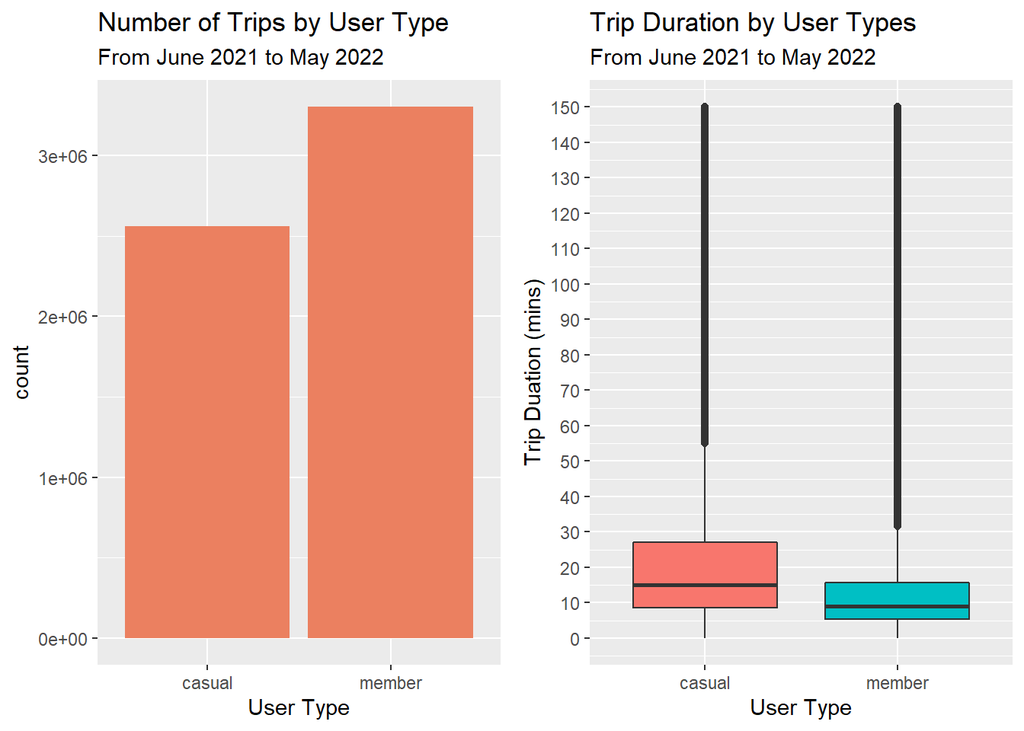

- The trips made by memberships was higher significantly than that of casual customers.
- However, the duration of trips made by casual user were longer than that of membership.

### **The difference between memberships and casual users in using different types of bike**

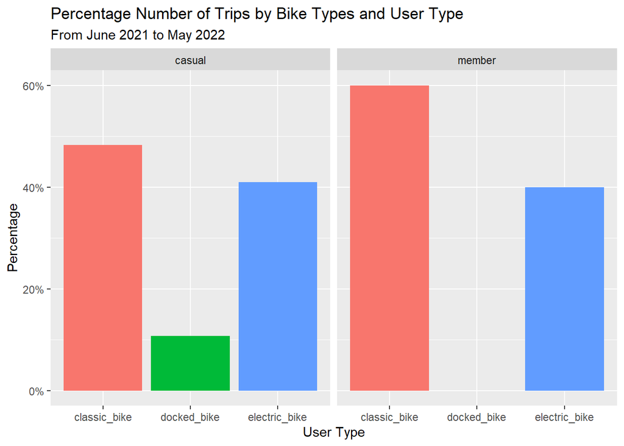

- The percentage of electric bike of casual and member user were quite equal, about 40%, while the classic bike proportion of membership was higher than casual user, 60% and 48% respectively. Memberships had no interest in docked bike, while 10% trips of cusual users were made by docked_bike.

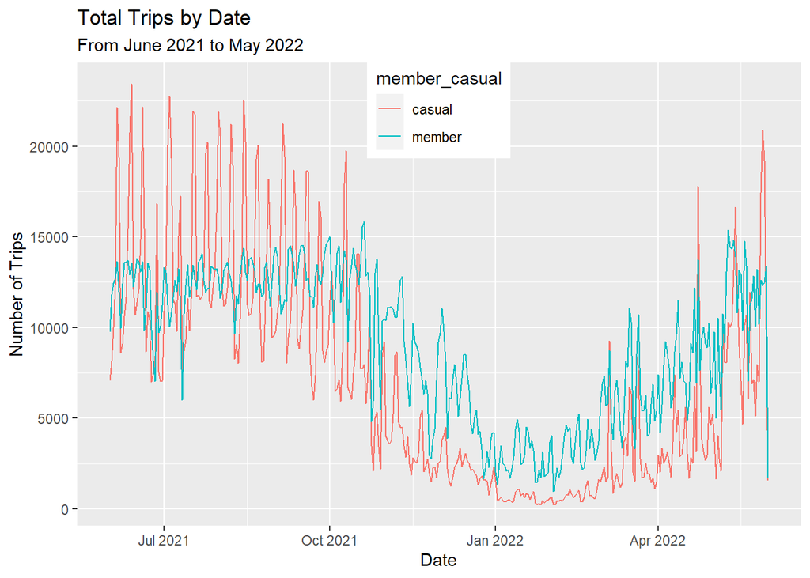

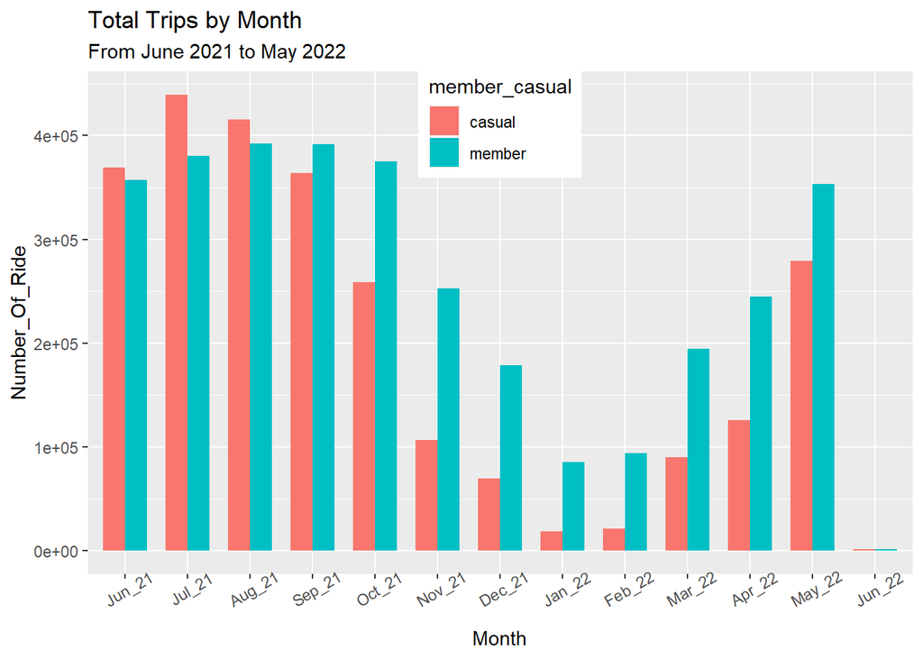

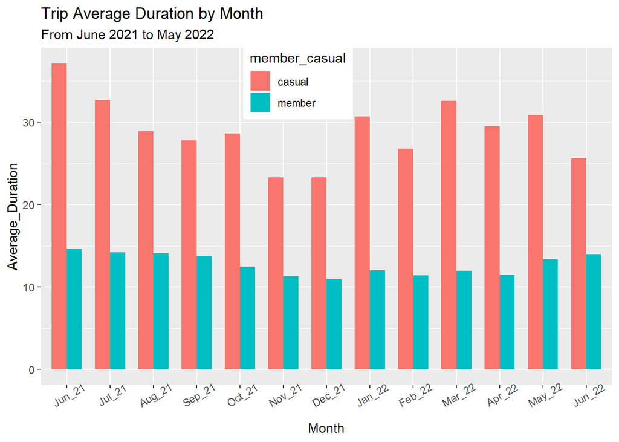

### **The difference between membership and casual users by days of week**

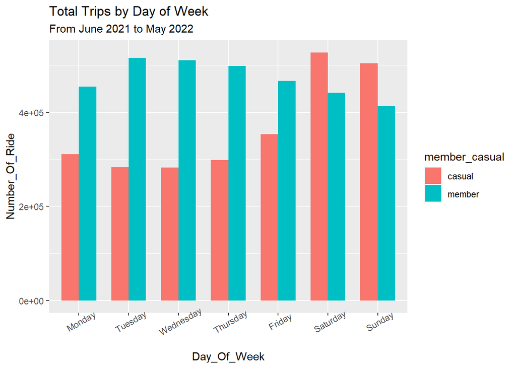

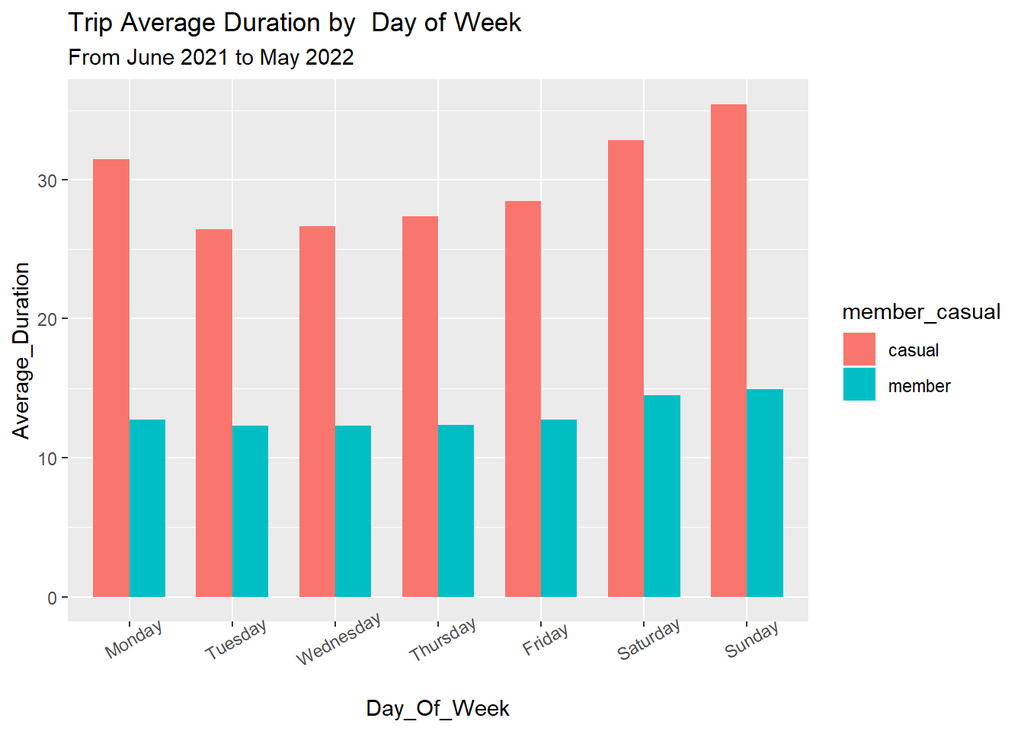

### **The difference between membership and casual users by Start time**

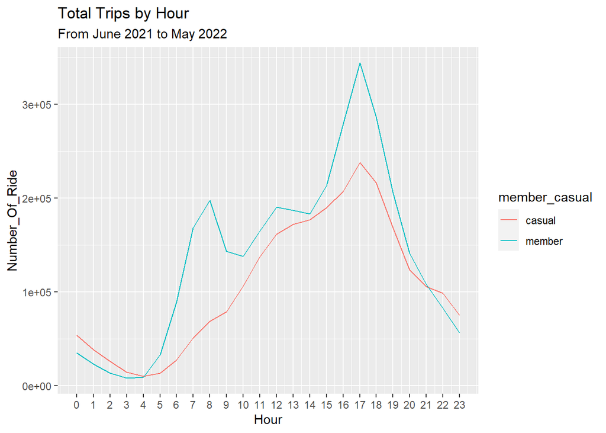

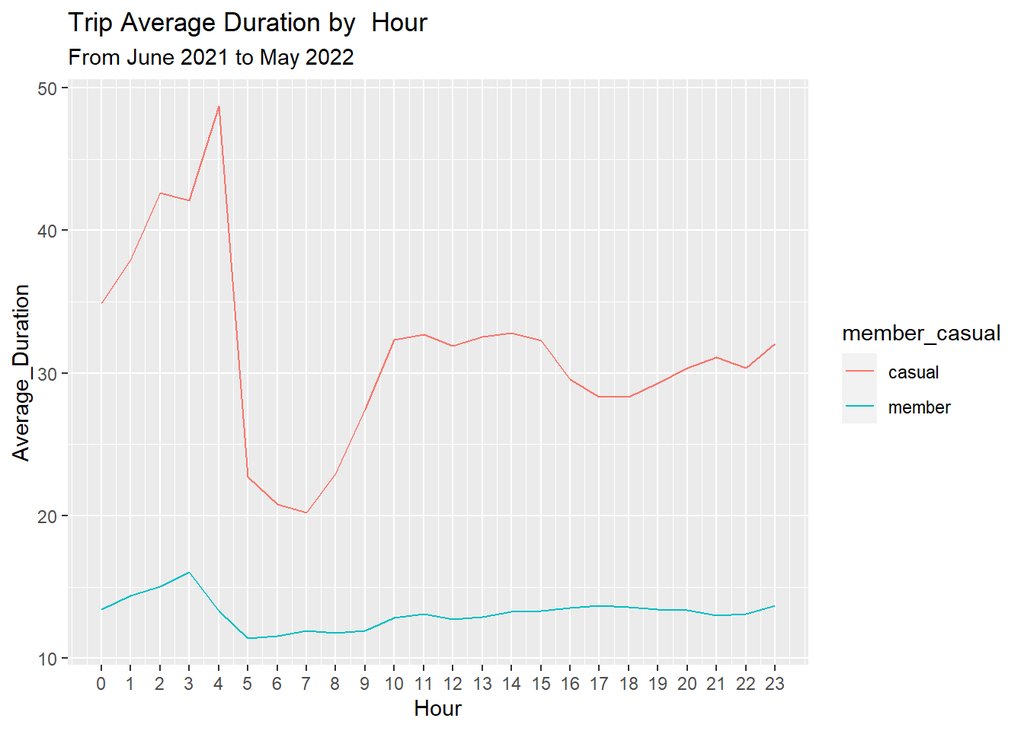

- The total trips made by both casual users and memberships increased from 4:00 am to 5:00 pm, then drop significantly toward midnight.
- A similar trends are seen in both casual users and membership, users having start time from 1am to 4am have longer using time rather than other start time.

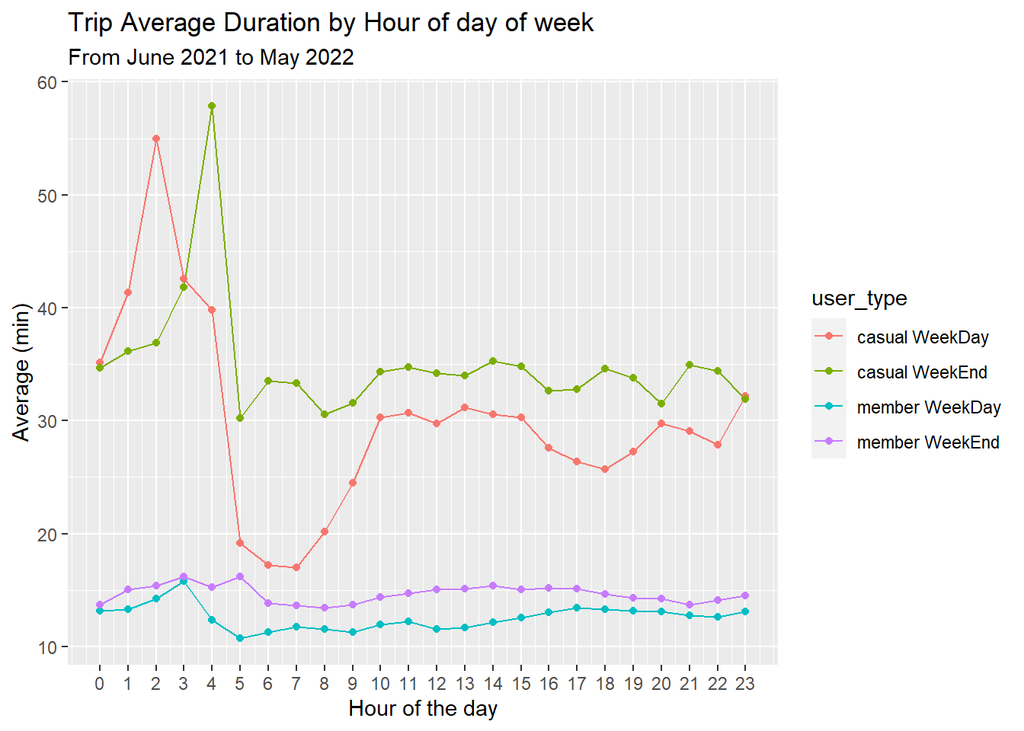

- Overall, in weekend, users tend to ride longer than in the week day.
- With casual customer on week days, trips having start time from 12am to 4am have duration time significantly longer than others, while trips having start time from 5am to 8am last shortest.

# Key Insignts and Recommendations:

### Key Insignts

- Casual users ride longer than membership users.
- The trips made by memberships in the work day are more than on the weekend, while casual riders make more trips on the weekend.
- The length of trips in the weekend of casual users is significantly higher than in the weekend, while the difference in trip duration of memberships is not significant.
- The peak seasons are summer and fall.
- The demands increase from 5am to 5pm for both memberships and casual riders.
- Large proportion of casual users take rides from stations near the beaches, while memberships likely start the rides from city centers.

### Marketing Recommendations to turn casual riders into memberships

- Provide promotions or discounts on weekend rides for casual members if they upgrade to memberships.
- Provide promotions for casual riders using services in workdays, so the company can increase the trips made by casual riders.
- Provide promotions or discounts in low seasons (spring and winter)
- Partner with restaurants and attractions near beaches to provide promotions and discounts for casual riders to encourage them to upgrade memberships because casual riders often start trips from these areas.